# Final Project

Rory King, Lucian Lang, Valentina Bernal

2022-12-06

## Problem Description

Jacob Kawalski has launched a real estate business and he is based in the King County district in his universe. Fortunately for him, the housing market has seen a recent boom and we will be helping him udnerstand how the pricing of the market works.

## Objective

To build a model for Jacob that will determine what factor(s) impact house prices in the market most heavily. By obtaining these factors, we will use the model to best predict the prices of a select few houses that Jacob has selected.

## Model implications

All models are described in detail within their respective files.

## Best model of choice: kNN and Regression Tree

Our most efficient and accurate model is the kNN model. It tests different factors of a house that may impact the total market price, and results in an accuracy measurement of which variables predict the price the best. Therefore, it is the most valuable when trying to consider the the most suitable recommendation for Jacob. With that being said, we will pair this with a regression tree because we need that model to predict the prices of the houses.

See ideal prediction variables in the kNN model

## Model #1

Our goal for this model was that we wanted to be able to create a model that gave a us the chance to look through all the different variables and how they effected the accuracy of the model. Being able to look at the output of the confusion matrix is a big benefit because of the detail it goes into, and because of this we were able to try many different variable combinations and get a read of their accuracy.

```r
#Loading and reading data
data <- read.csv('house_2.csv', header = TRUE)
names(data)
```

```
##  [1] "X"             "id"            "Year"          "Month"
##  [5] "Day"           "day_of_week"   "price"         "bedrooms"
##  [9] "bathrooms"     "sqft_living"   "sqft_lot"      "floors"
## [13] "waterfront"    "view"          "condition"     "grade"
## [17] "sqft_above"    "sqft_basement" "yr_built"      "yr_renovated"
## [21] "zipcode"       "lat"           "long"
```

```r
str(data)
```

```
## 'data.frame':    15053 obs. of  23 variables:
##  $ X            : int  1 2 3 4 5 6 7 8 9 10 ...
##  $ id           : num  3.30e+09 4.10e+09 7.52e+09 3.57e+09 7.20e+09 ...
##  $ Year         : int  2014 2014 2014 2014 2014 2014 2014 2015 2014 2014 ...
##  $ Month        : int  9 8 11 12 9 9 7 4 9 7 ...
##  $ Day          : int  5 12 12 16 11 5 8 28 9 25 ...
##  $ day_of_week  : int  5 2 3 2 4 5 2 2 2 5 ...
##  $ price        : num  400000 1650000 549000 434000 735000 ...
##  $ bedrooms     : int  6 4 5 3 4 4 4 5 5 3 ...
##  $ bathrooms    : num  3 3.5 1 2.25 3.5 2.5 2.5 2 4 2.25 ...
##  $ sqft_living  : int  3320 4610 1500 1750 3200 2200 2630 2260 3210 2370 ...
##  $ sqft_lot     : int  15600 12500 3978 9353 7605 5730 6185 11970 7200 10289 ...
##  $ floors       : num  1 2 2 1 2 2 2 1 2 1 ...
##  $ waterfront   : int  0 0 0 0 0 0 0 0 0 0 ...
##  $ view         : int  0 2 0 0 2 0 0 0 0 0 ...
##  $ condition    : int  4 3 3 3 3 3 3 4 3 4 ...
##  $ grade        : int  8 11 7 7 9 8 9 7 8 9 ...
##  $ sqft_above   : int  1660 4610 1500 1210 2500 2200 2630 1250 2410 1590 ...
##  $ sqft_basement: int  1660 0 0 540 700 0 0 1010 800 780 ...
##  $ yr_built     : int  1977 2003 1929 1987 2013 2003 1999 1962 2011 1977 ...
##  $ yr_renovated : int  0 0 0 0 0 0 0 0 0 0 ...
##  $ zipcode      : int  98092 98033 98117 98034 98198 98042 98056 98031 98019 98005 ...
##  $ lat          : num  47.3 47.7 47.7 47.7 47.3 ...
##  $ long         : num  -122 -122 -122 -122 -122 ...
```

```r
#Turning the price variable into categories
data$price <- as.numeric(as.character(data$price))

data1 <- data %>% mutate(price = case_when((price <= 300000) ~ 'cheap',
                         (300000< price) & (price <= 600000) ~ 'med low',
                         (600000< price) & (price <= 900000) ~ 'med high',
                         (price > 900000) ~ 'expensive'))
```

```r
#eliminating the variables that we don't want
data1 <- data1[ , -c(1:6,13,18 )]
names(data1)
```

```
##  [1] "price"        "bedrooms"     "bathrooms"    "sqft_living"  "sqft_lot"
##  [6] "floors"       "view"         "condition"    "grade"        "sqft_above"
## [11] "yr_built"     "yr_renovated" "zipcode"      "lat"          "long"
```

```r
#setting price as the factor
data1$price <- as.factor(data1$price)
```

```r
#Splitting data
set.seed(666)

train_index <- sample(1:nrow(data1), 0.7 * nrow(data1))
valid_index <- setdiff(1:nrow(data1), train_index)

train_df <- data1[train_index, ]
valid_df <- data1[valid_index, ]
```

```r
nrow(train_df)
```

```
## [1] 10537
```

```r
nrow(valid_df)
```

```
## [1] 4516
```

```r
#Normalising
train_norm <- train_df
valid_norm <- valid_df
```

```r
norm_values <- preProcess(train_df[, -c(1)],
                          method = c("center",
                                     "scale"))
train_norm[, -c(1)] <- predict(norm_values,
                                train_df[, -c(1)])

head(train_norm)
```

```
##          price   bedrooms  bathrooms sqft_living    sqft_lot      floors
## 1598   med low -0.3808227  0.5161057 -0.29567112 -0.28569567  0.94666619
## 12926  med low  0.6804650 -1.4490373 -1.09190539 -0.20795456  0.01624723
## 14944  med low  0.6804650  1.4986772 -0.09661256 -0.11880990 -0.91417173
## 13195 med high -0.3808227 -0.4664658 -0.64955302 -0.16060004 -0.91417173
## 7291  med high -0.3808227  1.8262011  1.93820834  2.97402688  0.94666619
## 14990  med low -0.3808227  0.1885819 -0.39520041 -0.08418705 -0.91417173
##             view  condition      grade  sqft_above   yr_built yr_renovated
## 1598  -0.3030222 -0.6236903  0.3006285  0.02476382  1.3566428    -0.207992
## 12926 -0.3030222  0.9142982 -1.4121169 -0.85887995 -1.5916280    -0.207992
## 14944 -0.3030222 -0.6236903  0.3006285 -0.53978637  0.3061095    -0.207992
## 13195 -0.3030222 -0.6236903 -0.5557442 -0.90797127 -0.6088711    -0.207992
## 7291   3.6486428 -0.6236903  1.1570013  1.33795663  0.9499847    -0.207992
## 14990 -0.3030222 -0.6236903 -0.5557442 -0.69933316  0.2383332    -0.207992
##          zipcode         lat        long
## 1598   0.8841315 -0.09848989 -1.09718330
## 12926  0.4517045  0.98375508 -0.93434235
## 14944 -0.5071552  0.92690843  0.72946732
## 13195 -1.4096114  0.56496081  0.05686341
## 7291  -0.6387634 -0.84613120  3.38448275
## 14990 -0.9583833  1.49681403 -0.37501910
```

```r
#predicting the normalised values of valid set
valid_norm[, -c(1)] <- predict(norm_values,
                                valid_df[, -c(1)])

head(valid_norm)
```

```
##        price   bedrooms  bathrooms sqft_living   sqft_lot      floors
## 3    med low  1.7417528 -1.4490373  -0.6274354 -0.2564311  0.94666619
## 6      cheap  0.6804650  0.5161057   0.1466812 -0.2163126  0.94666619
## 9    med low  1.7417528  2.4812487   1.2636210 -0.1826515  0.94666619
## 10  med high -0.3808227  0.1885819   0.3346810 -0.1119174 -0.91417173
## 12 expensive  2.8030405  1.1711534   1.0092684 -0.1826515  0.01624723
## 15     cheap -0.3808227 -0.4664658  -0.3952004 -0.1824225 -0.91417173
##          view  condition      grade sqft_above   yr_built yr_renovated
## 3  -0.3030222 -0.6236903 -0.5557442 -0.3434211 -1.4221871    -0.207992
## 6  -0.3030222 -0.6236903  0.3006285  0.5156770  1.0855374    -0.207992
## 9  -0.3030222 -0.6236903  0.3006285  0.7734064  1.3566428    -0.207992
## 10 -0.3030222  0.9142982  1.1570013 -0.2329656  0.2044450    -0.207992
## 12  2.3314211 -0.6236903  0.3006285  1.4729578 -2.0321742    -0.207992
## 15 -0.3030222  0.9142982 -0.5557442 -0.6625147  0.1027805    -0.207992
##       zipcode        lat       long
## 3   0.7149209  0.8750988 -1.1963039
## 6  -0.6951669 -1.5203756  0.4321056
## 9  -1.1275939  1.2478401  1.7560733
## 10 -1.3908103  0.2339550  0.3400651
## 12  0.7525233  0.5548867 -1.0476230
## 15 -0.9019798 -1.0799940  0.2763447
```

```r
#training the model with training data
knn_model <- caret::knn3(price ~ ., data = train_norm, k = 5)
knn_model
```

```
## 5-nearest neighbor model
## Training set outcome distribution:
##
##     cheap expensive  med high   med low
##      2229       955      2034      5319
```

```r
#prediction based on training split
knn_pred_train <- predict(knn_model, newdata = train_norm[, -c(1)],
                          type = "class")
head(knn_pred_train)
```

```
## [1] med low  med low  med low  med low  med high med low
## Levels: cheap expensive med high med low
```

```r
#Confusion matrix for the training data to see if it is strong enough to move on to the validation data
confusionMatrix(knn_pred_train, as.factor(train_norm[, 1]))
```

```
## Confusion Matrix and Statistics
##
##            Reference
## Prediction  cheap expensive med high med low
##   cheap      1842         0        8     297
##   expensive     1       723      121      27
##   med high      5       202     1455     279
##   med low     381        30      450    4716
##
## Overall Statistics
##
##                Accuracy : 0.8291
##                  95% CI : (0.8218, 0.8362)
##     No Information Rate : 0.5048
##     P-Value [Acc > NIR] : < 2.2e-16
##
##                   Kappa : 0.7357
##
##  Mcnemar's Test P-Value : 1.151e-13
##
## Statistics by Class:
##
##                      Class: cheap Class: expensive Class: med high
## Sensitivity                0.8264          0.75707          0.7153
## Specificity                0.9633          0.98445          0.9428
## Pos Pred Value             0.8579          0.82913          0.7496
## Neg Pred Value             0.9539          0.97600          0.9326
## Prevalence                 0.2115          0.09063          0.1930
## Detection Rate             0.1748          0.06862          0.1381
## Detection Prevalence       0.2038          0.08276          0.1842
## Balanced Accuracy          0.8948          0.87076          0.8291
##                      Class: med low
## Sensitivity                  0.8866
## Specificity                  0.8350
## Pos Pred Value               0.8456
## Neg Pred Value               0.8784
## Prevalence                   0.5048
## Detection Rate               0.4476
## Detection Prevalence         0.5293
## Balanced Accuracy            0.8608
```

```r
#creating prediction on validation set
knn_pred_valid <- predict(knn_model, newdata = valid_norm[, -c(1)],
                          type = "class")
head(knn_pred_valid)
```

```
## [1] med high  med low   med high  med high  expensive cheap
## Levels: cheap expensive med high med low
```

```r
#confusion matrix for validation model
confusionMatrix(knn_pred_valid, as.factor(valid_norm[, 1]))
```

```
## Confusion Matrix and Statistics
##
##            Reference
## Prediction  cheap expensive med high med low
##   cheap       712         1        1     179
##   expensive     0       306       85      12
##   med high      3       129      544     179
##   med low     240        15      276    1834
##
## Overall Statistics
##
##                Accuracy : 0.752
##                  95% CI : (0.7391, 0.7645)
##     No Information Rate : 0.488
##     P-Value [Acc > NIR] : < 2.2e-16
##
##                   Kappa : 0.6218
##
##  Mcnemar's Test P-Value : 2.976e-07
##
## Statistics by Class:
##
##                      Class: cheap Class: expensive Class: med high
## Sensitivity                0.7455          0.67849          0.6004
## Specificity                0.9492          0.97614          0.9139
## Pos Pred Value             0.7973          0.75931          0.6363
## Neg Pred Value             0.9329          0.96475          0.9011
## Prevalence                 0.2115          0.09987          0.2006
## Detection Rate             0.1577          0.06776          0.1205
## Detection Prevalence       0.1977          0.08924          0.1893
## Balanced Accuracy          0.8474          0.82732          0.7571
##                      Class: med low
## Sensitivity                  0.8321
## Specificity                  0.7703
## Pos Pred Value               0.7755
## Neg Pred Value               0.8280
## Prevalence                   0.4880
## Detection Rate               0.4061
## Detection Prevalence         0.5237
## Balanced Accuracy            0.8012
```

This was the highest accuracy that we could find after trying many different variable combinations, so it is what we believe to be the strongest.

## Model #2

### Examining Data with a Non-Linear Model

```r
data2 <- data
head(data2, 10)
```

```
##     X         id Year Month Day day_of_week   price bedrooms bathrooms
## 1   1 3298600340 2014     9   5           5  400000        6      3.00
## 2   2 4104500181 2014     8  12           2 1650000        4      3.50
## 3   3 7518504775 2014    11  12           3  549000        5      1.00
## 4   4 3574801310 2014    12  16           2  434000        3      2.25
## 5   5 7203600560 2014     9  11           4  735000        4      3.50
## 6   6 7885800160 2014     9   5           5  299900        4      2.50
## 7   7 7954300330 2014     7   8           2  585000        4      2.50
## 8   8 9122500080 2015     4  28           2  275000        5      2.00
## 9   9 2619950060 2014     9   9           2  465000        5      4.00
## 10 10 9542850320 2014     7  25           5  790000        3      2.25
##    sqft_living sqft_lot floors waterfront view condition grade sqft_above
## 1         3320    15600      1          0    0         4     8       1660
## 2         4610    12500      2          0    2         3    11       4610
## 3         1500     3978      2          0    0         3     7       1500
```

[output cut: 18 more lines]

Subsetting into variables used only for model, decided to select these specifc variables as they are the more critical factors in calculating prices for houses in today’s world. With the data already being from a specific area, geographically, the need to include those varibles was minimal.Subsetting our data to the factors that drive price in this dataset is what is reflected in this model.

```r
data2 <- data2[, c("price", "bedrooms", "bathrooms", "sqft_living", "condition", "grade")]
head(data)
```

```
##   X         id Year Month Day day_of_week   price bedrooms bathrooms
## 1 1 3298600340 2014     9   5           5  400000        6      3.00
## 2 2 4104500181 2014     8  12           2 1650000        4      3.50
## 3 3 7518504775 2014    11  12           3  549000        5      1.00
## 4 4 3574801310 2014    12  16           2  434000        3      2.25
## 5 5 7203600560 2014     9  11           4  735000        4      3.50
## 6 6 7885800160 2014     9   5           5  299900        4      2.50
##   sqft_living sqft_lot floors waterfront view condition grade sqft_above
## 1        3320    15600      1          0    0         4     8       1660
## 2        4610    12500      2          0    2         3    11       4610
## 3        1500     3978      2          0    0         3     7       1500
## 4        1750     9353      1          0    0         3     7       1210
## 5        3200     7605      2          0    2         3     9       2500
## 6        2200     5730      2          0    0         3     8       2200
##   sqft_basement yr_built yr_renovated zipcode     lat     long
## 1          1660     1977            0   98092 47.2983 -122.166
## 2             0     2003            0   98033 47.6508 -122.203
## 3             0     1929            0   98117 47.6811 -122.383
## 4           540     1987            0   98034 47.7305 -122.225
## 5           700     2013            0   98198 47.3443 -122.327
## 6             0     2003            0   98042 47.3482 -122.153
```

Making all variables numeric for regression purposes. We want to make sure we connect hard links among our dataset and allow for reflection. Having all the variables matched up, will allow for correklation to be more efficient in this non-linear model.

```r
data2 <- data2 %>% mutate_if(is.integer, as.numeric)
str(data2)
```

```
## 'data.frame':    15053 obs. of  6 variables:
##  $ price      : num  400000 1650000 549000 434000 735000 ...
##  $ bedrooms   : num  6 4 5 3 4 4 4 5 5 3 ...
##  $ bathrooms  : num  3 3.5 1 2.25 3.5 2.5 2.5 2 4 2.25 ...
##  $ sqft_living: num  3320 4610 1500 1750 3200 2200 2630 2260 3210 2370 ...
##  $ condition  : num  4 3 3 3 3 3 3 4 3 4 ...
##  $ grade      : num  8 11 7 7 9 8 9 7 8 9 ...
```

Creating Regression Model with the varibles listed, and having price be the Target Variable.

```r
price_model_non <- lm(price ~ bedrooms + bathrooms + sqft_living +
                         condition + grade,
                       data = data2)
summary(price_model_non)
```

```
##
## Call:
## lm(formula = price ~ bedrooms + bathrooms + sqft_living + condition +
##     grade, data = data2)
##
## Residuals:
##     Min      1Q  Median      3Q     Max
## -997680 -132882  -22317   94768 4374025
##
## Coefficients:
##               Estimate Std. Error t value Pr(>|t|)
## (Intercept) -7.470e+05  2.144e+04 -34.843  < 2e-16 ***
## bedrooms    -4.031e+04  2.651e+03 -15.205  < 2e-16 ***
## bathrooms   -1.694e+04  4.085e+03  -4.146  3.4e-05 ***
## sqft_living  2.108e+02  4.188e+00  50.322  < 2e-16 ***
## condition    6.468e+04  3.093e+03  20.911  < 2e-16 ***
## grade        1.044e+05  2.736e+03  38.173  < 2e-16 ***
## ---
## Signif. codes:  0 '***' 0.001 '**' 0.01 '*' 0.05 '.' 0.1 ' ' 1
##
## Residual standard error: 241400 on 15047 degrees of freedom
## Multiple R-squared:  0.5541, Adjusted R-squared:  0.554
## F-statistic:  3740 on 5 and 15047 DF,  p-value: < 2.2e-16
```

Checking Correlation Points

```r
vif(price_model_non)
```

```
##    bedrooms   bathrooms sqft_living   condition       grade
##    1.586148    2.555004    3.818958    1.042997    2.646598
```

```r
durbinWatsonTest(price_model_non)
```

```
##  lag Autocorrelation D-W Statistic p-value
##    1      0.01193991      1.975948   0.106
##  Alternative hypothesis: rho != 0
```

```r
price_model_non_step <- step(price_model_non, direction = "both")
```

```
## Start:  AIC=373151.3
## price ~ bedrooms + bathrooms + sqft_living + condition + grade
##
##               Df  Sum of Sq        RSS    AIC
## <none>                      8.7715e+14 373151
## - bathrooms    1 1.0022e+12 8.7816e+14 373167
## - bedrooms     1 1.3477e+13 8.9063e+14 373379
## - condition    1 2.5491e+13 9.0264e+14 373581
## - grade        1 8.4947e+13 9.6210e+14 374541
## - sqft_living  1 1.4762e+14 1.0248e+15 375491
```

Reflecting on the model.

```r
summary(price_model_non_step)
```

```
##
## Call:
## lm(formula = price ~ bedrooms + bathrooms + sqft_living + condition +
##     grade, data = data2)
##
## Residuals:
##     Min      1Q  Median      3Q     Max
## -997680 -132882  -22317   94768 4374025
##
## Coefficients:
##               Estimate Std. Error t value Pr(>|t|)
## (Intercept) -7.470e+05  2.144e+04 -34.843  < 2e-16 ***
## bedrooms    -4.031e+04  2.651e+03 -15.205  < 2e-16 ***
## bathrooms   -1.694e+04  4.085e+03  -4.146  3.4e-05 ***
## sqft_living  2.108e+02  4.188e+00  50.322  < 2e-16 ***
## condition    6.468e+04  3.093e+03  20.911  < 2e-16 ***
## grade        1.044e+05  2.736e+03  38.173  < 2e-16 ***
## ---
## Signif. codes:  0 '***' 0.001 '**' 0.01 '*' 0.05 '.' 0.1 ' ' 1
##
## Residual standard error: 241400 on 15047 degrees of freedom
## Multiple R-squared:  0.5541, Adjusted R-squared:  0.554
## F-statistic:  3740 on 5 and 15047 DF,  p-value: < 2.2e-16
```

```r
vif(price_model_non_step)
```

```
##    bedrooms   bathrooms sqft_living   condition       grade
##    1.586148    2.555004    3.818958    1.042997    2.646598
```

```r
durbinWatsonTest(price_model_non_step)
```

[output not shown]

Data Mining Approach with the same non-linear agression model.

```r
price_model_mining <- lm(price ~ bedrooms + bathrooms + sqft_living + condition + grade, data = data2)

summary(price_model_mining)
```

```
##
## Call:
## lm(formula = price ~ bedrooms + bathrooms + sqft_living + condition +
##     grade, data = data2)
##
## Residuals:
##     Min      1Q  Median      3Q     Max
## -997680 -132882  -22317   94768 4374025
##
## Coefficients:
##               Estimate Std. Error t value Pr(>|t|)
## (Intercept) -7.470e+05  2.144e+04 -34.843  < 2e-16 ***
## bedrooms    -4.031e+04  2.651e+03 -15.205  < 2e-16 ***
## bathrooms   -1.694e+04  4.085e+03  -4.146  3.4e-05 ***
## sqft_living  2.108e+02  4.188e+00  50.322  < 2e-16 ***
## condition    6.468e+04  3.093e+03  20.911  < 2e-16 ***
## grade        1.044e+05  2.736e+03  38.173  < 2e-16 ***
## ---
## Signif. codes:  0 '***' 0.001 '**' 0.01 '*' 0.05 '.' 0.1 ' ' 1
##
## Residual standard error: 241400 on 15047 degrees of freedom
## Multiple R-squared:  0.5541, Adjusted R-squared:  0.554
## F-statistic:  3740 on 5 and 15047 DF,  p-value: < 2.2e-16
```

Predicting with main dataset

```r
price_model_predict <- predict(price_model_mining, data2)

accuracy(price_model_predict, data2$price)
```

```
##                     ME     RMSE      MAE       MPE     MAPE
## Test set -6.892836e-08 241393.9 158193.6 -10.49882 32.85462
```

Predicting the test file with non-linear model, expected range of prices among the test data. Split into upper, lower, and middle preditions on the price of the households.

```r
new <- read.csv("house_test_2.csv", header = TRUE)


price_model_predict_new <- predict(price_model_mining, newdata = new, interval = "confidence")

price_model_predict_new
```

```
##          fit       lwr       upr
## 1   188957.4  180175.5  197739.3
## 2   315386.5  305100.3  325672.8
## 3   244747.8  235929.7  253565.9
## 4   395346.8  386712.7  403980.9
## 5   641639.1  635754.8  647523.4
## 6   566357.1  551813.7  580900.6
## 7   580761.8  572696.8  588826.8
## 8   441452.2  429921.6  452982.9
## 9   563282.8  555451.3  571114.3
## 10  616629.9  611006.3  622253.6
## 11  652478.9  646643.7  658314.2
## 12  437572.3  430869.9  444274.7
## 13 1171100.8 1158943.1 1183258.4
## 14  500786.2  493738.7  507833.7
## 15 1018225.1 1009447.5 1027002.6
## 16  393910.6  386599.6  401221.7
## 17 1169921.6 1155984.0 1183859.2
## 18  693956.5  687240.8  700672.1
## 19 1107646.4 1096235.3 1119057.5
## 20  836714.8  829758.5  843671.0
```

```r
gvlma(price_model_mining)
```

```
##
## Call:
## lm(formula = price ~ bedrooms + bathrooms + sqft_living + condition +
##     grade, data = data2)
##
## Coefficients:
## (Intercept)     bedrooms    bathrooms  sqft_living    condition        grade
##   -746969.7     -40308.6     -16937.6        210.8      64680.7     104428.0
##
##
## ASSESSMENT OF THE LINEAR MODEL ASSUMPTIONS
## USING THE GLOBAL TEST ON 4 DEGREES-OF-FREEDOM:
## Level of Significance =  0.05
##
## Call:
##  gvlma(x = price_model_mining)
##
##                        Value   p-value                   Decision
## Global Stat        485310.52 0.000e+00 Assumptions NOT satisfied!
## Skewness            23246.06 0.000e+00 Assumptions NOT satisfied!
## Kurtosis           460276.54 0.000e+00 Assumptions NOT satisfied!
## Link Function        1761.57 0.000e+00 Assumptions NOT satisfied!
## Heteroscedasticity     26.35 2.851e-07 Assumptions NOT satisfied!
```

After predicting the 20 houses details in the other test file, this non-linear regression model is useful for looking at a variance of prices for the details uncovered. Their is no true answer the actual price, but it provides for a range of price based on the neighboring households within the data set. Although this isn’t the best model for usage, it is great for house searching to see what you could potentially negotiate a house too, lower than it’s asking price. Considering a few more variables may be effcient as well.

## Model #3

### Regression tree

Filtering for the necessary variables

```r
house_data1 <- data[, -c(1:6,13,18 )]
names(house_data1)
```

```
##  [1] "price"        "bedrooms"     "bathrooms"    "sqft_living"  "sqft_lot"
##  [6] "floors"       "view"         "condition"    "grade"        "sqft_above"
## [11] "yr_built"     "yr_renovated" "zipcode"      "lat"          "long"
```

```r
str(house_data1)
```

```
## 'data.frame':    15053 obs. of  15 variables:
##  $ price       : num  400000 1650000 549000 434000 735000 ...
##  $ bedrooms    : int  6 4 5 3 4 4 4 5 5 3 ...
##  $ bathrooms   : num  3 3.5 1 2.25 3.5 2.5 2.5 2 4 2.25 ...
##  $ sqft_living : int  3320 4610 1500 1750 3200 2200 2630 2260 3210 2370 ...
##  $ sqft_lot    : int  15600 12500 3978 9353 7605 5730 6185 11970 7200 10289 ...
##  $ floors      : num  1 2 2 1 2 2 2 1 2 1 ...
##  $ view        : int  0 2 0 0 2 0 0 0 0 0 ...
##  $ condition   : int  4 3 3 3 3 3 3 4 3 4 ...
##  $ grade       : int  8 11 7 7 9 8 9 7 8 9 ...
##  $ sqft_above  : int  1660 4610 1500 1210 2500 2200 2630 1250 2410 1590 ...
##  $ yr_built    : int  1977 2003 1929 1987 2013 2003 1999 1962 2011 1977 ...
##  $ yr_renovated: int  0 0 0 0 0 0 0 0 0 0 ...
##  $ zipcode     : int  98092 98033 98117 98034 98198 98042 98056 98031 98019 98005 ...
##  $ lat         : num  47.3 47.7 47.7 47.7 47.3 ...
##  $ long        : num  -122 -122 -122 -122 -122 ...
```

Training-validation split

```r
set.seed(666)

train_index1 <- sample(1:nrow(house_data1), 0.7 * nrow(house_data1))
valid_index1 <- setdiff(1:nrow(house_data1), train_index1)

train_df1 <- house_data1[train_index1, ]
valid_df1 <- house_data1[valid_index1, ]
```

```r
nrow(train_df1)
```

```
## [1] 10537
```

```r
nrow(valid_df1)
```

```
## [1] 4516
```

### Building the regression tree

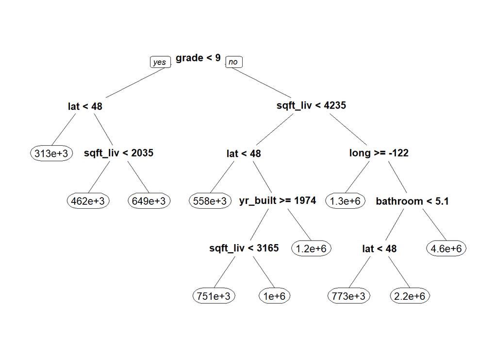

```r
# First, a large tree

regr_tree1 <- rpart(price ~ .,
                    data = train_df1, method = "anova", maxdepth = 20)
prp(regr_tree1)
```

```r
#To look at accuracy
predict_train <- predict(regr_tree1, train_df1)
accuracy(predict_train, train_df1$price)
```

```
##                   ME     RMSE      MAE       MPE     MAPE
## Test set 6.40212e-12 201922.2 129192.3 -10.34775 26.50896
```

What is the accuracy with the validation data on this tree?

```r
predict_valid <- predict(regr_tree1, valid_df1)
accuracy(predict_valid, valid_df1$price)
```

```
##                ME     RMSE      MAE       MPE     MAPE
## Test set 797.3408 236203.8 137386.9 -10.18958 26.63821
```

### A simpler shallower tree

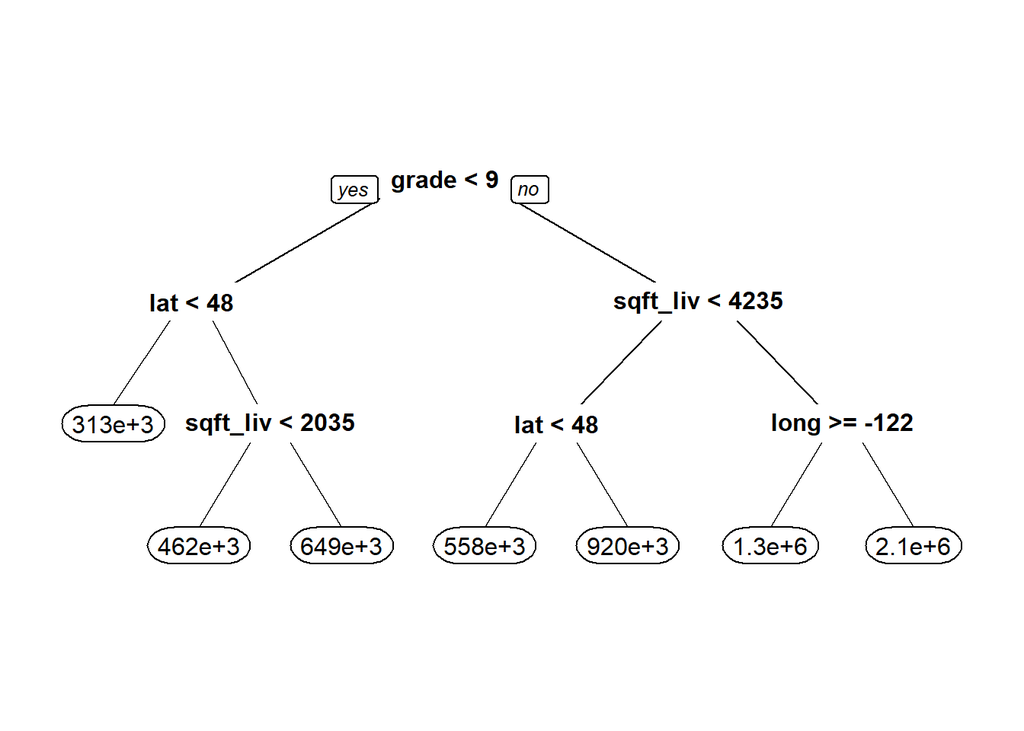

```r
regr_tr_shallow1 <- rpart(price ~ .,
                            data = train_df1, method = "anova",
                            minbucket = 2, maxdepth = 3)
prp(regr_tr_shallow1)
```

Data on the shallow tree

```r
predict_train_shallow <- predict(regr_tr_shallow1, train_df1)
accuracy(predict_train_shallow, train_df1$price)
```

```
##                    ME     RMSE      MAE       MPE     MAPE
## Test set 2.962905e-12 226834.9 137452.7 -11.07003 27.54389
```

What is the accuracy with the validation data on the shallow tree?

```r
predict_valid_shallow <- predict(regr_tr_shallow1, valid_df1)
accuracy(predict_valid_shallow, valid_df1$price)
```

```
##                ME     RMSE      MAE       MPE     MAPE
## Test set 6143.352 239955.1 141300.3 -10.28038 27.18523
```

The root mean squared error is relatively similar for both trees (training and validation), which is good. However, they are all around 200k st. deviations away from the regression line data points which may indicate that the chosen variables vary in the impact they have on house pricing. Our other model will observe different variables.

### Predicting the new record

```r
names(new)
```

```
##  [1] "X"             "id"            "Year"          "Month"
##  [5] "Day"           "day_of_week"   "bedrooms"      "bathrooms"
##  [9] "sqft_living"   "sqft_lot"      "floors"        "waterfront"
## [13] "view"          "condition"     "grade"         "sqft_above"
## [17] "sqft_basement" "yr_built"      "yr_renovated"  "zipcode"
## [21] "lat"           "long"
```

```r
newdata1 <- new[, -c(1:6,12, 17 )]
names(newdata1)
```

```
##  [1] "bedrooms"     "bathrooms"    "sqft_living"  "sqft_lot"     "floors"
##  [6] "view"         "condition"    "grade"        "sqft_above"   "yr_built"
## [11] "yr_renovated" "zipcode"      "lat"          "long"
```

### New data on large tree

```r
new_regr_tree1 <- predict(regr_tree1, newdata = newdata1)
new_regr_tree1
```

```
##         1         2         3         4         5         6         7         8
##  461920.4  461920.4  313310.8  461920.4  313310.8 1209067.2  648945.7  313310.8
##         9        10        11        12        13        14        15        16
##  461920.4  648945.7  313310.8  461920.4 1005523.2  461920.4 1005523.2  313310.8
##        17        18        19        20
## 1005523.2  648945.7 1005523.2  750513.0
```

### New data prediction on shallow tree

```r
new_shallow_tree1 <- predict(regr_tr_shallow1, newdata = newdata1)
new_shallow_tree1
```

```
##        1        2        3        4        5        6        7        8
## 461920.4 461920.4 313310.8 461920.4 313310.8 920103.9 648945.7 313310.8
##        9       10       11       12       13       14       15       16
## 461920.4 648945.7 313310.8 461920.4 920103.9 461920.4 920103.9 313310.8
##       17       18       19       20
## 920103.9 648945.7 920103.9 920103.9
```